# Customer Segmentation

```python
from IPython.display import Image

Image(filename=r"C:\Users\Dalkeith J Thomas\Downloads\Page 1 CS Proj.gif")
```

**This project was created using a fictional dataset sourced from Kaggle. I will be using it to create a targeted marketing campaign based on demographics and spending habits of consumers.**

```python
Image(filename=r"C:\Users\Dalkeith J Thomas\Downloads\Page 1 CS Proj (2).gif")
```

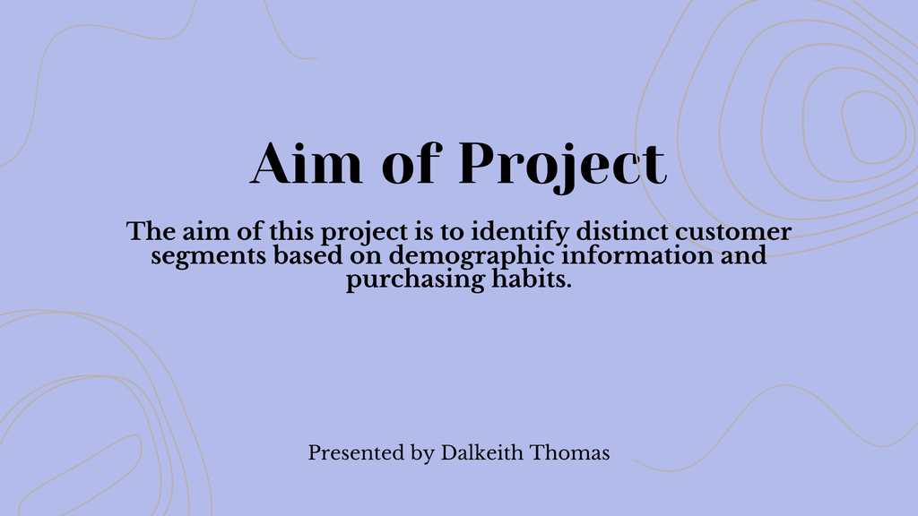

```python
Image(filename=r"C:\Users\Dalkeith J Thomas\Downloads\CS Aim.png")
```

**Firstly,we must import the necessary libraries.**

```python
import pandas as pd
import matplotlib.pyplot as plt
import numpy as np
import seaborn as sns
```

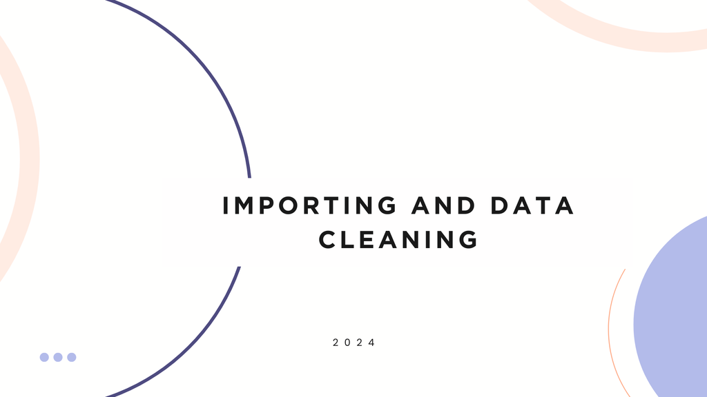

```python
Image(filename=r"C:\Users\Dalkeith J Thomas\Downloads\CS Import and Clean.png")
```

```python
path=r"C:\Users\Dalkeith J Thomas\marketing_campaign.csv"

df=pd.read_csv(path,sep="\t")
```

**I will be doing the customary pre-processing checks, including the shape of the data,count,summary statistics and missing values.**

```python
df.head()
```

|  | ID | Year_Birth | Education | Marital_Status | Income | Kidhome | Teenhome | Dt_Customer | Recency | MntWines | ... | NumWebVisitsMonth | AcceptedCmp3 | AcceptedCmp4 | AcceptedCmp5 | AcceptedCmp1 | AcceptedCmp2 | Complain | Z_CostContact | Z_Revenue | Response |
| --- | --- | --- | --- | --- | --- | --- | --- | --- | --- | --- | --- | --- | --- | --- | --- | --- | --- | --- | --- | --- | --- |
| 0 | 5524 | 1957 | Graduation | Single | 58138.0 | 0 | 0 | 04-09-2012 | 58 | 635 | ... | 7 | 0 | 0 | 0 | 0 | 0 | 0 | 3 | 11 | 1 |
| 1 | 2174 | 1954 | Graduation | Single | 46344.0 | 1 | 1 | 08-03-2014 | 38 | 11 | ... | 5 | 0 | 0 | 0 | 0 | 0 | 0 | 3 | 11 | 0 |
| 2 | 4141 | 1965 | Graduation | Together | 71613.0 | 0 | 0 | 21-08-2013 | 26 | 426 | ... | 4 | 0 | 0 | 0 | 0 | 0 | 0 | 3 | 11 | 0 |
| 3 | 6182 | 1984 | Graduation | Together | 26646.0 | 1 | 0 | 10-02-2014 | 26 | 11 | ... | 6 | 0 | 0 | 0 | 0 | 0 | 0 | 3 | 11 | 0 |
| 4 | 5324 | 1981 | PhD | Married | 58293.0 | 1 | 0 | 19-01-2014 | 94 | 173 | ... | 5 | 0 | 0 | 0 | 0 | 0 | 0 | 3 | 11 | 0 |

5 rows × 29 columns

```python
 print("SHAPE".center(50,'*'))
 print(df.shape)
```

```
**********************SHAPE***********************
(2240, 29)
```

```python
print("The total number of datapoints are",len(df))
```

```
The total number of datapoints are 2240
```

```python
df.describe()
```

|  | ID | Year_Birth | Income | Kidhome | Teenhome | Recency | MntWines | MntFruits | MntMeatProducts | MntFishProducts | ... | NumWebVisitsMonth | AcceptedCmp3 | AcceptedCmp4 | AcceptedCmp5 | AcceptedCmp1 | AcceptedCmp2 | Complain | Z_CostContact | Z_Revenue | Response |
| --- | --- | --- | --- | --- | --- | --- | --- | --- | --- | --- | --- | --- | --- | --- | --- | --- | --- | --- | --- | --- | --- |
| count | 2240.000000 | 2240.000000 | 2216.000000 | 2240.000000 | 2240.000000 | 2240.000000 | 2240.000000 | 2240.000000 | 2240.000000 | 2240.000000 | ... | 2240.000000 | 2240.000000 | 2240.000000 | 2240.000000 | 2240.000000 | 2240.000000 | 2240.000000 | 2240.0 | 2240.0 | 2240.000000 |
| mean | 5592.159821 | 1968.805804 | 52247.251354 | 0.444196 | 0.506250 | 49.109375 | 303.935714 | 26.302232 | 166.950000 | 37.525446 | ... | 5.316518 | 0.072768 | 0.074554 | 0.072768 | 0.064286 | 0.013393 | 0.009375 | 3.0 | 11.0 | 0.149107 |
| std | 3246.662198 | 11.984069 | 25173.076661 | 0.538398 | 0.544538 | 28.962453 | 336.597393 | 39.773434 | 225.715373 | 54.628979 | ... | 2.426645 | 0.259813 | 0.262728 | 0.259813 | 0.245316 | 0.114976 | 0.096391 | 0.0 | 0.0 | 0.356274 |
| min | 0.000000 | 1893.000000 | 1730.000000 | 0.000000 | 0.000000 | 0.000000 | 0.000000 | 0.000000 | 0.000000 | 0.000000 | ... | 0.000000 | 0.000000 | 0.000000 | 0.000000 | 0.000000 | 0.000000 | 0.000000 | 3.0 | 11.0 | 0.000000 |
| 25% | 2828.250000 | 1959.000000 | 35303.000000 | 0.000000 | 0.000000 | 24.000000 | 23.750000 | 1.000000 | 16.000000 | 3.000000 | ... | 3.000000 | 0.000000 | 0.000000 | 0.000000 | 0.000000 | 0.000000 | 0.000000 | 3.0 | 11.0 | 0.000000 |
| 50% | 5458.500000 | 1970.000000 | 51381.500000 | 0.000000 | 0.000000 | 49.000000 | 173.500000 | 8.000000 | 67.000000 | 12.000000 | ... | 6.000000 | 0.000000 | 0.000000 | 0.000000 | 0.000000 | 0.000000 | 0.000000 | 3.0 | 11.0 | 0.000000 |
| 75% | 8427.750000 | 1977.000000 | 68522.000000 | 1.000000 | 1.000000 | 74.000000 | 504.250000 | 33.000000 | 232.000000 | 50.000000 | ... | 7.000000 | 0.000000 | 0.000000 | 0.000000 | 0.000000 | 0.000000 | 0.000000 | 3.0 | 11.0 | 0.000000 |
| max | 11191.000000 | 1996.000000 | 666666.000000 | 2.000000 | 2.000000 | 99.000000 | 1493.000000 | 199.000000 | 1725.000000 | 259.000000 | ... | 20.000000 | 1.000000 | 1.000000 | 1.000000 | 1.000000 | 1.000000 | 1.000000 | 3.0 | 11.0 | 1.000000 |

8 rows × 26 columns

**Firstly, we see that there aren't any missing columns for the vast majority of variables.There are some columns, which are unnecessary for the analysis, we are doing. Those rows, are the promotion related columns and as such I will be removing them.**

```python
df=df.drop(columns=['AcceptedCmp3','AcceptedCmp4','AcceptedCmp5','AcceptedCmp1','AcceptedCmp2','Complain','Z_CostContact','Z_Revenue','Response'])
```

```python
df.head()
```

|  | ID | Year_Birth | Education | Marital_Status | Income | Kidhome | Teenhome | Dt_Customer | Recency | MntWines | MntFruits | MntMeatProducts | MntFishProducts | MntSweetProducts | MntGoldProds | NumDealsPurchases | NumWebPurchases | NumCatalogPurchases | NumStorePurchases | NumWebVisitsMonth |
| --- | --- | --- | --- | --- | --- | --- | --- | --- | --- | --- | --- | --- | --- | --- | --- | --- | --- | --- | --- | --- |
| 0 | 5524 | 1957 | Graduation | Single | 58138.0 | 0 | 0 | 04-09-2012 | 58 | 635 | 88 | 546 | 172 | 88 | 88 | 3 | 8 | 10 | 4 | 7 |
| 1 | 2174 | 1954 | Graduation | Single | 46344.0 | 1 | 1 | 08-03-2014 | 38 | 11 | 1 | 6 | 2 | 1 | 6 | 2 | 1 | 1 | 2 | 5 |
| 2 | 4141 | 1965 | Graduation | Together | 71613.0 | 0 | 0 | 21-08-2013 | 26 | 426 | 49 | 127 | 111 | 21 | 42 | 1 | 8 | 2 | 10 | 4 |
| 3 | 6182 | 1984 | Graduation | Together | 26646.0 | 1 | 0 | 10-02-2014 | 26 | 11 | 4 | 20 | 10 | 3 | 5 | 2 | 2 | 0 | 4 | 6 |
| 4 | 5324 | 1981 | PhD | Married | 58293.0 | 1 | 0 | 19-01-2014 | 94 | 173 | 43 | 118 | 46 | 27 | 15 | 5 | 5 | 3 | 6 | 5 |

**Below, I define the variables, that will be used.**

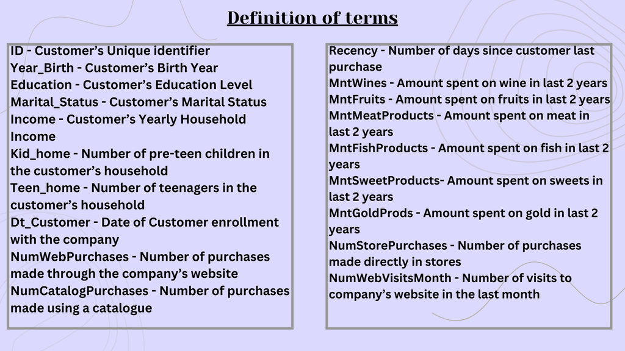

```python
Image(filename=r"C:\Users\Dalkeith J Thomas\Downloads\CS Definition of Terms.png")
```

**Next, I will be looking at the data types and ensuring that they are of the correct format**

```python
print("INFO".center(50,"*"))
df.info()
```

```
***********************INFO***********************
<class 'pandas.core.frame.DataFrame'>
RangeIndex: 2240 entries, 0 to 2239
Data columns (total 20 columns):
 #   Column               Non-Null Count  Dtype
---  ------               --------------  -----
 0   ID                   2240 non-null   int64
 1   Year_Birth           2240 non-null   int64
 2   Education            2240 non-null   object
 3   Marital_Status       2240 non-null   object
 4   Income               2216 non-null   float64
 5   Kidhome              2240 non-null   int64
 6   Teenhome             2240 non-null   int64
 7   Dt_Customer          2240 non-null   object
 8   Recency              2240 non-null   int64
 9   MntWines             2240 non-null   int64
 10  MntFruits            2240 non-null   int64
 11  MntMeatProducts      2240 non-null   int64
 12  MntFishProducts      2240 non-null   int64
 13  MntSweetProducts     2240 non-null   int64
 14  MntGoldProds         2240 non-null   int64
 15  NumDealsPurchases    2240 non-null   int64
 16  NumWebPurchases      2240 non-null   int64
 17  NumCatalogPurchases  2240 non-null   int64
 18  NumStorePurchases    2240 non-null   int64
 19  NumWebVisitsMonth    2240 non-null   int64
dtypes: float64(1), int64(16), object(3)
memory usage: 350.1+ KB
```

**The Dt_Customer is set as an object, however in keeping with best data practices, I will be resetting it to a date time data type.**

```python
df['Dt_Customer']=pd.to_datetime(df['Dt_Customer'],format='%d-%m-%Y')
```

**I have converted to column to datetime, next I will be investigating the missing values for Income.**

```python
df.isna().sum()
```

```
ID                      0
Year_Birth              0
Education               0
Marital_Status          0
Income                 24
Kidhome                 0
Teenhome                0
Dt_Customer             0
Recency                 0
MntWines                0
MntFruits               0
MntMeatProducts         0
MntFishProducts         0
MntSweetProducts        0
MntGoldProds            0
NumDealsPurchases       0
NumWebPurchases         0
NumCatalogPurchases     0
NumStorePurchases       0
NumWebVisitsMonth       0
dtype: int64
```

**There are several methods one may use to deal with the missing variables in the income column. Some may opt to drop the missing rows altogether, since the dataset is relatively large relative to the missing rows. However, I believe this is last resort, and as a result I will be looking into the distribution of income, to possibly predict said missing values.**

```python
pip install scipy
```

```python
from scipy.stats import shapiro
Income_for_test = df["Income"].dropna()
statistic, p_value = shapiro(Income_for_test)
if p_value > 0.05:
    print(f"Income appears to be normally distributed (p-value = {p_value:.4f})")
else:
    print(f"Income appears to not be normally distributed (p-value = {p_value:.4f})")
```

```
Income appears to not be normally distributed (p-value = 0.0000)
```

**The result from the shapiro test implies that income is not normally distributed, for robustness, I will also use the jarque-bera test, which is commonly used for small to medium sized datasets in economterics.**

```python
from scipy.stats import jarque_bera

stat, p_value = jarque_bera(Income_for_test)

alpha = 0.05  # Typical significance level
if p_value > alpha:
    print(f"Income appears to be normally distributed (p-value={p_value:.4f}")
else:
    print(f"Income appears to not be normally distributed (p-value={p_value:.4f})")
```

```
Income appears to not be normally distributed (p-value=0.0000)
```

**This provides strong evidence that the data is not normally distributed, as a result, imputation of the mean would not suffice as an accurate representation of the missing values. However, due to the size of the dataset, using the median of the entire dataset may not be the ideal imputation.It is well documented within economic literature that income is correlated with education. As such, I will be looking at the Income distribution within each education subsection.**

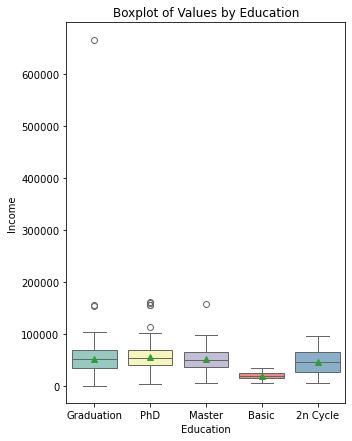

```python
# To create a boxplot
fig, ax = plt.subplots(figsize=(5, 7))
sns.boxplot(x = "Education", y = "Income", showmeans=True, data=df, ax=ax,hue="Education",palette="Set3")

plt.xlabel("Education")
plt.ylabel("Income")
plt.title("Boxplot of Values by Education")
plt.show()
```

**The boxplots provide strong evidence of outliers, instead of deleting the missing data completely, I will input the data with the median for each group.**

```python
median_income_by_education = df.groupby('Education')['Income'].transform('median')
df['Income'] = df['Income'].fillna(median_income_by_education)
```

```python
df.isna().sum()
```

```
ID                     0
Year_Birth             0
Education              0
Marital_Status         0
Income                 0
Kidhome                0
Teenhome               0
Dt_Customer            0
Recency                0
MntWines               0
MntFruits              0
MntMeatProducts        0
MntFishProducts        0
MntSweetProducts       0
MntGoldProds           0
NumDealsPurchases      0
NumWebPurchases        0
NumCatalogPurchases    0
NumStorePurchases      0
NumWebVisitsMonth      0
dtype: int64
```

**I will be an age field,given that age is more suitable for analysis relative to year of birth.I will also find the age when the customer signed up. In addition, to finding out how long a customer has been with the company**

```python
df['Customer_Age']= 2024 - df['Year_Birth']
```

```python
df['Age_of_Enrol'] = df['Dt_Customer'].dt.year - df['Year_Birth']
```

```python
df['Customer_Tenure'] = 2024 - df['Dt_Customer'].dt.year
```

```python
df=df.drop(columns=['Dt_Customer'])
```

```python
df.describe()
```

|  | ID | Year_Birth | Income | Kidhome | Teenhome | Recency | MntWines | MntFruits | MntMeatProducts | MntFishProducts | MntSweetProducts | MntGoldProds | NumDealsPurchases | NumWebPurchases | NumCatalogPurchases | NumStorePurchases | NumWebVisitsMonth | Customer_Age | Age_of_Enrol | Customer_Tenure |
| --- | --- | --- | --- | --- | --- | --- | --- | --- | --- | --- | --- | --- | --- | --- | --- | --- | --- | --- | --- | --- |
| count | 2240.000000 | 2240.000000 | 2240.000000 | 2240.000000 | 2240.000000 | 2240.000000 | 2240.000000 | 2240.000000 | 2240.000000 | 2240.000000 | 2240.000000 | 2240.000000 | 2240.000000 | 2240.000000 | 2240.000000 | 2240.000000 | 2240.000000 | 2240.000000 | 2240.000000 | 2240.000000 |
| mean | 5592.159821 | 1968.805804 | 52242.594866 | 0.444196 | 0.506250 | 49.109375 | 303.935714 | 26.302232 | 166.950000 | 37.525446 | 27.062946 | 44.021875 | 2.325000 | 4.084821 | 2.662054 | 5.790179 | 5.316518 | 55.194196 | 44.222321 | 10.971875 |
| std | 3246.662198 | 11.984069 | 25039.061738 | 0.538398 | 0.544538 | 28.962453 | 336.597393 | 39.773434 | 225.715373 | 54.628979 | 41.280498 | 52.167439 | 1.932238 | 2.778714 | 2.923101 | 3.250958 | 2.426645 | 11.984069 | 12.022855 | 0.684554 |
| min | 0.000000 | 1893.000000 | 1730.000000 | 0.000000 | 0.000000 | 0.000000 | 0.000000 | 0.000000 | 0.000000 | 0.000000 | 0.000000 | 0.000000 | 0.000000 | 0.000000 | 0.000000 | 0.000000 | 0.000000 | 28.000000 | 16.000000 | 10.000000 |
| 25% | 2828.250000 | 1959.000000 | 35538.750000 | 0.000000 | 0.000000 | 24.000000 | 23.750000 | 1.000000 | 16.000000 | 3.000000 | 1.000000 | 9.000000 | 1.000000 | 2.000000 | 0.000000 | 3.000000 | 3.000000 | 47.000000 | 36.000000 | 11.000000 |
| 50% | 5458.500000 | 1970.000000 | 51498.500000 | 0.000000 | 0.000000 | 49.000000 | 173.500000 | 8.000000 | 67.000000 | 12.000000 | 8.000000 | 24.000000 | 2.000000 | 4.000000 | 2.000000 | 5.000000 | 6.000000 | 54.000000 | 43.000000 | 11.000000 |
| 75% | 8427.750000 | 1977.000000 | 68289.750000 | 1.000000 | 1.000000 | 74.000000 | 504.250000 | 33.000000 | 232.000000 | 50.000000 | 33.000000 | 56.000000 | 3.000000 | 6.000000 | 4.000000 | 8.000000 | 7.000000 | 65.000000 | 54.000000 | 11.000000 |
| max | 11191.000000 | 1996.000000 | 666666.000000 | 2.000000 | 2.000000 | 99.000000 | 1493.000000 | 199.000000 | 1725.000000 | 259.000000 | 263.000000 | 362.000000 | 15.000000 | 27.000000 | 28.000000 | 13.000000 | 20.000000 | 131.000000 | 121.000000 | 12.000000 |

**There seems to be a few outliers in the data, I will have to remove this row to correct the data.**

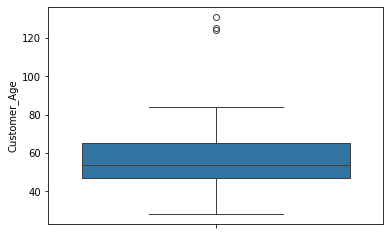

```python
sns.boxplot(y="Customer_Age",data=df)
```

```python
# Calculate z-scores for age
df['z_score_age'] = (df['Customer_Age'] - df['Customer_Age'].mean()) / df['Customer_Age'].std()

threshold = 3

# Extract outliers based on z-scores for age
age_outliers = df[df['z_score_age'].abs() > threshold]

print("Extracted age outliers:")
print(age_outliers)
```

```
Extracted age outliers:
        ID  Year_Birth Education Marital_Status   Income  Kidhome  Teenhome  \
192   7829        1900  2n Cycle       Divorced  36640.0        1         0
239  11004        1893  2n Cycle         Single  60182.0        0         1
339   1150        1899       PhD       Together  83532.0        0         0

     Recency  MntWines  MntFruits  ...  MntGoldProds  NumDealsPurchases  \
192       99        15          6  ...            25                  1
239       23         8          0  ...             2                  1
339       36       755        144  ...           224                  1

     NumWebPurchases  NumCatalogPurchases  NumStorePurchases  \
192                2                    1                  2
239                1                    0                  2
339                4                    6                  4

     NumWebVisitsMonth  Customer_Age  Age_of_Enrol  Customer_Tenure  \
192                  5           124           113               11
239                  4           131           121               10
339                  1           125           114               11

     z_score_age
192     5.741439
239     6.325548
339     5.824883

[3 rows x 23 columns]
```

```python
# Remove age outliers from the original data
df = df.query('z_score_age.abs() <= @threshold')
print(df)
```

```
         ID  Year_Birth   Education Marital_Status   Income  Kidhome  \
0      5524        1957  Graduation         Single  58138.0        0
1      2174        1954  Graduation         Single  46344.0        1
2      4141        1965  Graduation       Together  71613.0        0
3      6182        1984  Graduation       Together  26646.0        1
4      5324        1981         PhD        Married  58293.0        1
...     ...         ...         ...            ...      ...      ...
2235  10870        1967  Graduation        Married  61223.0        0
2236   4001        1946         PhD       Together  64014.0        2
2237   7270        1981  Graduation       Divorced  56981.0        0
2238   8235        1956      Master       Together  69245.0        0
2239   9405        1954         PhD        Married  52869.0        1

      Teenhome  Recency  MntWines  MntFruits  ...  MntGoldProds  \
0            0       58       635         88  ...            88
```

[output cut: 51 more lines]

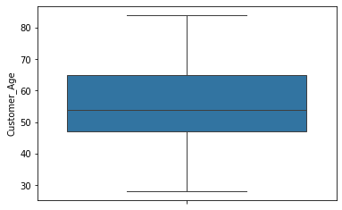

```python
sns.boxplot(y="Customer_Age",data=df)
```

```python
df=df.drop(columns=['z_score_age'])
```

```python
df.head()
```

|  | ID | Year_Birth | Education | Marital_Status | Income | Kidhome | Teenhome | Recency | MntWines | MntFruits | ... | MntSweetProducts | MntGoldProds | NumDealsPurchases | NumWebPurchases | NumCatalogPurchases | NumStorePurchases | NumWebVisitsMonth | Customer_Age | Age_of_Enrol | Customer_Tenure |
| --- | --- | --- | --- | --- | --- | --- | --- | --- | --- | --- | --- | --- | --- | --- | --- | --- | --- | --- | --- | --- | --- |
| 0 | 5524 | 1957 | Graduation | Single | 58138.0 | 0 | 0 | 58 | 635 | 88 | ... | 88 | 88 | 3 | 8 | 10 | 4 | 7 | 67 | 55 | 12 |
| 1 | 2174 | 1954 | Graduation | Single | 46344.0 | 1 | 1 | 38 | 11 | 1 | ... | 1 | 6 | 2 | 1 | 1 | 2 | 5 | 70 | 60 | 10 |
| 2 | 4141 | 1965 | Graduation | Together | 71613.0 | 0 | 0 | 26 | 426 | 49 | ... | 21 | 42 | 1 | 8 | 2 | 10 | 4 | 59 | 48 | 11 |
| 3 | 6182 | 1984 | Graduation | Together | 26646.0 | 1 | 0 | 26 | 11 | 4 | ... | 3 | 5 | 2 | 2 | 0 | 4 | 6 | 40 | 30 | 10 |
| 4 | 5324 | 1981 | PhD | Married | 58293.0 | 1 | 0 | 94 | 173 | 43 | ... | 27 | 15 | 5 | 5 | 3 | 6 | 5 | 43 | 33 | 10 |

5 rows × 22 columns

```python
Image(filename=r"C:\Users\Dalkeith J Thomas\Downloads\CS Definition of Terms.gif")
```

```python
Num_cat_of_interest=df[['Income','Recency','Customer_Age','Age_of_Enrol','NumDealsPurchases','NumWebPurchases','NumStorePurchases','NumWebVisitsMonth']]
```

```python
print(round(Num_cat_of_interest.mean(),2))
```

```
Income               52232.03
Recency                 49.10
Customer_Age            55.10
Age_of_Enrol            44.13
NumDealsPurchases        2.33
NumWebPurchases          4.09
NumStorePurchases        5.79
NumWebVisitsMonth        5.32
dtype: float64
```

```python
Cat_vars=df[['Education','Marital_Status',]]
```

```python
for var in Cat_vars:
    unique_var=df[var].unique()
    unique_count = df[var].nunique()
    print(f"The '{var}' Variable has {unique_count} unique values,these are {unique_var}")
```

```
The 'Education' Variable has 5 unique values,these are ['Graduation' 'PhD' 'Master' 'Basic' '2n Cycle']
The 'Marital_Status' Variable has 8 unique values,these are ['Single' 'Together' 'Married' 'Divorced' 'Widow' 'Alone' 'Absurd' 'YOLO']
```

```python
replacements_dict={'Graduation':'High School Diploma','PhD':'Doctorate','Master':"master's degree",'Basic':"bachelor's degree",'2n Cycle':'Graduate Student'}
df['Education'] = df['Education'].replace(replacements_dict)
```

```python
for var in Cat_vars:
    unique_v_count=df[var].value_counts()
    print(unique_v_count)
```

```
High School Diploma    1127
Doctorate               485
master's degree         370
Graduate Student        201
bachelor's degree        54
Name: Education, dtype: int64
Married     864
Together    579
Single      479
Divorced    231
Widow        77
Alone         3
Absurd        2
YOLO          2
Name: Marital_Status, dtype: int64
```

**The categorical variables have 5 and 8 values respectively,however the marital status variable has a few odd entries, and as such they need to be adjusted. These entries imply that one is single, as such I will be adjusting this.**

```python
# Creating a dictionary to be used
replace_dict = {'YOLO': 'Single', 'Alone': 'Single', 'Absurd': 'Single'}

# Apply replace using the dictionary
df['Marital_Status'] = df['Marital_Status'].replace(replace_dict)
```

```python
for var in Cat_vars:
    unique_v_count=df[var].value_counts()
    print(unique_v_count)
```

```
High School Diploma    1127
Doctorate               485
master's degree         370
Graduate Student        201
bachelor's degree        54
Name: Education, dtype: int64
Married     864
Together    579
Single      486
Divorced    231
Widow        77
Name: Marital_Status, dtype: int64
```

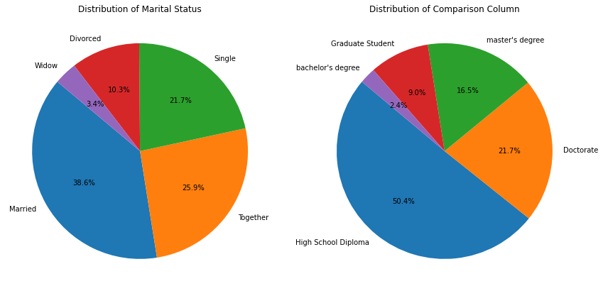

```python
# Get the counts for 'Marriage' and the Education column
marriage_stat = df['Marital_Status'].value_counts()
Education_stat = df['Education'].value_counts()

# Create the figure and subplots (1 row, 2 columns)
fig, (ax1, ax2) = plt.subplots(1, 2, figsize=(12, 6))

# Create the first pie chart (Marriage)
ax1.pie(marriage_stat, labels=marriage_stat.index, autopct='%1.1f%%', startangle=140)
ax1.set_title('Distribution of Marital Status')

# Create the second pie chart (Comparison Column)
ax2.pie(Education_stat, labels=Education_stat.index, autopct='%1.1f%%', startangle=140)
ax2.set_title('Distribution of Comparison Column')

# Optional: Adjust layout for better spacing
plt.tight_layout()

# Display the plot
plt.show()
```

**I will be creating a variable entitled household size, we can further analyze this and create segments based on different households, since income is the income for the entire household.**

```python
# Creating a dictionary to be used
replace_dict_h = {'Together': 2, 'Alone': 1, 'Married': 2,'Widow':1,'Single':1,'Divorced':1}
df['Household_Size']=df['Marital_Status'].replace(replace_dict_h)+df['Kidhome']+df['Teenhome']
```

```python
print(df['Household_Size'])
```

```
0       1
1       3
2       2
3       3
4       3
       ..
2235    3
2236    5
2237    1
2238    3
2239    4
Name: Household_Size, Length: 2237, dtype: int64
```

```python
df=df.drop(columns=['Kidhome','Teenhome'])
```

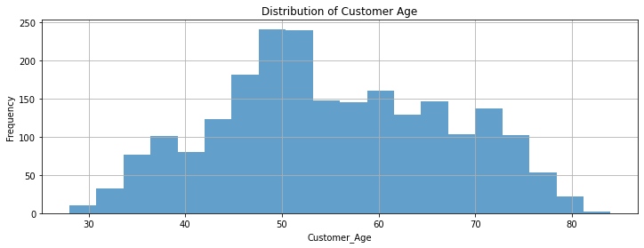

```python
# Create the figure with subplots
fig, ax = plt.subplots(figsize=(12, 4))


ax.hist(df['Customer_Age'], bins=20, alpha=0.7, label='All')
ax.set_xlabel('Customer_Age')
ax.set_ylabel('Frequency')
ax.set_title('Distribution of Customer Age')
ax.grid(True)


# Display the plot
plt.show()
```

**The majority of the customer clients fall into the middle aged adulthood region.**

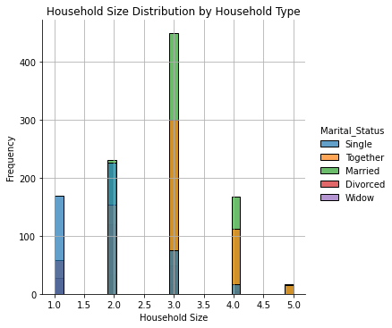

```python
# Create a distribution plot with 'household_size' on the y-axis and colored by 'household_type'
sns.displot(x='Household_Size', hue='Marital_Status', data=df, kind='hist', alpha=0.7)

# Customize the plot (optional)
plt.xlabel('Household Size')
plt.ylabel('Frequency')
plt.title('Household Size Distribution by Household Type')
plt.grid(True)


# Display the plot
plt.show()
```

```python
print(df.groupby("Marital_Status")["Household_Size"].mean())
```

```
Marital_Status
Divorced    2.004329
Married     2.967593
Single      1.872428
Together    2.981002
Widow       1.870130
Name: Household_Size, dtype: float64
```

**Persons who are together or Married have the largest household sizes, whereas, widows have the smallest household sizes. This is comprehensible, as widows typically have adult children and as such tend to have smaller households. Similarly, single individuals also have smaller households.**

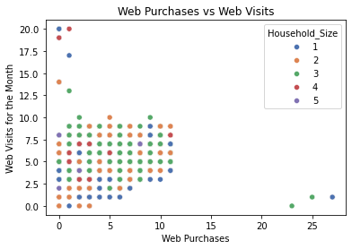

```python
sns.scatterplot(
    x="NumWebPurchases",
    y="NumWebVisitsMonth",
    hue="Household_Size",
    data=df,
    palette="deep"
)

# Add labels and title
plt.xlabel("Web Purchases")
plt.ylabel("Web Visits for the Month")
plt.title("Web Purchases vs Web Visits")
plt.show()
```

```python
correlation=df['NumWebVisitsMonth'].corr(df['NumWebPurchases'])
print(correlation)
```

```
-0.05625049652430647
```

**This that web purchases and visits for the month have a minimal negative relationship. Though it is important to note that correlation doesn't imply causation. A positive and stronger relationship would be more beneficial for the business.As such, there may need to be adjustments made in terms of web design, in addition to the services offered and possibly a marketing campaign aimed to increase its online sales.**

```python
Image(filename=r"C:\Users\Dalkeith J Thomas\Downloads\Page 1 CS Proj (3).gif")
```

**I will be defining RFM segments below, Recency is already sorted, but I need to create monetary and frequency columns.**

```python
df['Monetary']=df['MntWines']+df['MntFruits']+df['MntMeatProducts']+df['MntFishProducts']+df['MntSweetProducts']+df['MntGoldProds']
```

```python
df=df.drop(columns=['MntWines','MntFruits','MntMeatProducts','MntFishProducts','MntSweetProducts','MntGoldProds'])
```

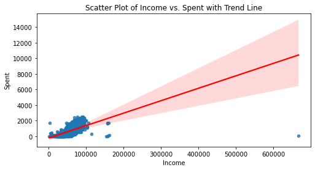

```python
plt.figure(figsize=(8, 4))
sns.regplot(x='Income', y='Monetary', data=df, scatter_kws={'s': 20}, line_kws={'color': 'red'})

plt.title('Scatter Plot of Income vs. Spent with Trend Line')
plt.xlabel('Income')
plt.ylabel('Spent')
plt.show()
```

**As one would expect there is a positive correlation between income and the amount spent.**

```python
df['Frequency']=df['NumDealsPurchases']+df['NumWebPurchases']+df['NumCatalogPurchases']+df['NumWebVisitsMonth']
```

```python
df=df.drop(columns=['NumDealsPurchases','NumWebPurchases','NumCatalogPurchases','NumWebVisitsMonth','NumStorePurchases'])
```

```python
df.head()
```

|  | ID | Year_Birth | Education | Marital_Status | Income | Recency | Customer_Age | Age_of_Enrol | Customer_Tenure | Household_Size | Monetary | Frequency |
| --- | --- | --- | --- | --- | --- | --- | --- | --- | --- | --- | --- | --- |
| 0 | 5524 | 1957 | High School Diploma | Single | 58138.0 | 58 | 67 | 55 | 12 | 1 | 1617 | 28 |
| 1 | 2174 | 1954 | High School Diploma | Single | 46344.0 | 38 | 70 | 60 | 10 | 3 | 27 | 9 |
| 2 | 4141 | 1965 | High School Diploma | Together | 71613.0 | 26 | 59 | 48 | 11 | 2 | 776 | 15 |
| 3 | 6182 | 1984 | High School Diploma | Together | 26646.0 | 26 | 40 | 30 | 10 | 3 | 53 | 10 |
| 4 | 5324 | 1981 | Doctorate | Married | 58293.0 | 94 | 43 | 33 | 10 | 3 | 422 | 18 |

**I will be using several variables to cluster the rest, I will not need to include, thus I am going to create a subset of data.**

```python
df_clus=df[['Education','Marital_Status','Customer_Age','Income','Recency','Household_Size','Age_of_Enrol']]
df_to_scale=df[['Recency','Frequency','Monetary']]
```

**K-Means clustering is widely favored for its simplicity, ease of implementation, and computational efficiency, making it suitable for large datasets. It converges quickly and performs well with well-separated, spherical clusters, providing clear and interpretable results. Despite this, K-Means clustering is not without its disadvantages, as it is particularly sensitive to outliers, as a result, I will be scaling the features prior to implementation.**

```python
# Standardize the features
from sklearn.preprocessing import StandardScaler
scaler = StandardScaler()
df_scaled = scaler.fit_transform(df_to_scale)
```

**Next, we must determine the ideal number of clusters, by using the elbow method.**

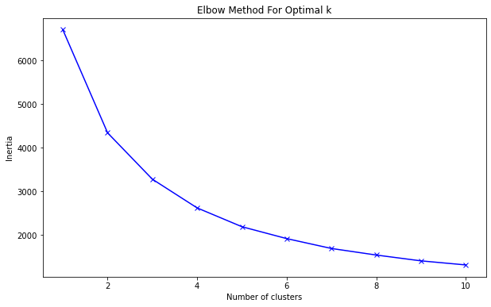

```python
from sklearn.cluster import KMeans
# Elbow method to find the optimal number of clusters
inertia = []
K = range(1, 11)

for k in K:
    kmeans = KMeans(n_clusters=k, random_state=42)
    kmeans.fit(df_scaled)
    inertia.append(kmeans.inertia_)

# Plotting the curve
plt.figure(figsize=(10, 6))
plt.plot(K, inertia, 'bx-')
plt.xlabel('Number of clusters')
plt.ylabel('Inertia')
plt.title('Elbow Method For Optimal k')
plt.show()
```

**The diagram doesnt showcase a clear elbow point, as a result I am going to use silhouette and CHI analysis, to better pinpoint the optimal number of clusters.**

```python
from sklearn.metrics import silhouette_score

k_range = range(2, 11)


silhouette_scores = []


for k in k_range:
  kmeans = KMeans(n_clusters=k)
  kmeans.fit(df_scaled)
  silhouette_score_val = silhouette_score(df_scaled, kmeans.labels_)
  silhouette_scores.append(silhouette_score_val)

# Finding the optimum
best_k = k_range[silhouette_scores.index(max(silhouette_scores))]

# Printing the silhouette
for k, score in zip(k_range, silhouette_scores):
  print(f"Number of clusters (k): {k}, Silhouette Score: {score:.4f}")

# Print the chosen k with the highest silhouette score
print(f"\nOptimal Number of Clusters (based on Silhouette Analysis): {best_k}")
```

```
Number of clusters (k): 2, Silhouette Score: 0.3338
Number of clusters (k): 3, Silhouette Score: 0.3115
Number of clusters (k): 4, Silhouette Score: 0.3275
Number of clusters (k): 5, Silhouette Score: 0.3368
Number of clusters (k): 6, Silhouette Score: 0.3320
Number of clusters (k): 7, Silhouette Score: 0.3170
Number of clusters (k): 8, Silhouette Score: 0.3016
Number of clusters (k): 9, Silhouette Score: 0.3062
Number of clusters (k): 10, Silhouette Score: 0.3059

Optimal Number of Clusters (based on Silhouette Analysis): 5
```

```python
from sklearn.metrics import calinski_harabasz_score

data = df_scaled
k_range = range(2, 11)

# Creating a dictionary to store
chi_scores = {}

#To loop through the different k values
for k in k_range:
  kmeans = KMeans(n_clusters=k)
  kmeans.fit(data)

  # Calculate CHI score
  chi_score_val = calinski_harabasz_score(data, kmeans.labels_)

  # Store scores in dictionaries
  chi_scores[k] = chi_score_val

# Find k with CHI score
best_k_chi = max(chi_scores, key=chi_scores.get)

print("\nCalinski-Harabasz Scores:")
for k, score in chi_scores.items():
  print(f"  Number of clusters (k): {k}, Score: {score:.4f}")

#To print the optimal K
print("\nPossible Optimal k values based on:")
print(f"  Calinski-Harabasz Index: {best_k_chi}")
```

```
Calinski-Harabasz Scores:
  Number of clusters (k): 2, Score: 1219.0665
  Number of clusters (k): 3, Score: 1170.2675
  Number of clusters (k): 4, Score: 1163.2905
  Number of clusters (k): 5, Score: 1156.8945
  Number of clusters (k): 6, Score: 1119.3503
  Number of clusters (k): 7, Score: 1107.2522
  Number of clusters (k): 8, Score: 1072.5606
  Number of clusters (k): 9, Score: 1054.5546
  Number of clusters (k): 10, Score: 1021.6389

Possible Optimal k values based on:
  Calinski-Harabasz Index: 2
```

**The optimal number of clusters is 2, the elbow method implies two clusters, however this is not as clear. The silhouette analysis, finds 2 clusters to be second-most optimal, whereas the Calinski-Harabasz index find it to be most optimal. As such, I will be working with two clusters. However, prior to clustering, I will be placing the continuous variables into bins.**

```python
df.describe()
```

|  | ID | Year_Birth | Income | Recency | Customer_Age | Age_of_Enrol | Customer_Tenure | Household_Size | Monetary | Frequency |
| --- | --- | --- | --- | --- | --- | --- | --- | --- | --- | --- |
| count | 2237.000000 | 2237.000000 | 2237.000000 | 2237.000000 | 2237.000000 | 2237.000000 | 2237.000000 | 2237.000000 | 2237.000000 | 2237.000000 |
| mean | 5590.726419 | 1968.901654 | 52232.033304 | 49.104604 | 55.098346 | 44.126062 | 10.972284 | 2.595887 | 605.743406 | 14.395619 |
| std | 3245.118591 | 11.701917 | 25044.375878 | 28.956073 | 11.701917 | 11.739008 | 0.684704 | 0.907305 | 601.840466 | 5.437763 |
| min | 0.000000 | 1940.000000 | 1730.000000 | 0.000000 | 28.000000 | 16.000000 | 10.000000 | 1.000000 | 5.000000 | 0.000000 |
| 25% | 2829.000000 | 1959.000000 | 35523.000000 | 24.000000 | 47.000000 | 36.000000 | 11.000000 | 2.000000 | 69.000000 | 10.000000 |
| 50% | 5455.000000 | 1970.000000 | 51479.000000 | 49.000000 | 54.000000 | 43.000000 | 11.000000 | 3.000000 | 396.000000 | 14.000000 |
| 75% | 8427.000000 | 1977.000000 | 68281.000000 | 74.000000 | 65.000000 | 54.000000 | 11.000000 | 3.000000 | 1045.000000 | 18.000000 |
| max | 11191.000000 | 1996.000000 | 666666.000000 | 99.000000 | 84.000000 | 73.000000 | 12.000000 | 5.000000 | 2525.000000 | 44.000000 |

```python
df['Income_Group']=pd.qcut(df['Income'],q=3,labels=['Low','Middle','High'])
```

```python
# Defining bins
bins = [0, 45, 65, 100]
labels = ['45 and below', 'Greater than 45 and less than 65', '65 and over']

# Creating the column
df['Age_Group'] = pd.cut(df['Customer_Age'], bins=bins, labels=labels)
print(df)
```

```
         ID  Year_Birth            Education Marital_Status   Income  Recency  \
0      5524        1957  High School Diploma         Single  58138.0       58
1      2174        1954  High School Diploma         Single  46344.0       38
2      4141        1965  High School Diploma       Together  71613.0       26
3      6182        1984  High School Diploma       Together  26646.0       26
4      5324        1981            Doctorate        Married  58293.0       94
...     ...         ...                  ...            ...      ...      ...
2235  10870        1967  High School Diploma        Married  61223.0       46
2236   4001        1946            Doctorate       Together  64014.0       56
2237   7270        1981  High School Diploma       Divorced  56981.0       91
2238   8235        1956      master's degree       Together  69245.0        8
2239   9405        1954            Doctorate        Married  52869.0       40

      Customer_Age  Age_of_Enrol  Customer_Tenure  Household_Size  Monetary  \
0               67            55               12               1      1617
```

[output cut: 25 more lines]

```python
df.head()
```

|  | ID | Year_Birth | Education | Marital_Status | Income | Recency | Customer_Age | Age_of_Enrol | Customer_Tenure | Household_Size | Monetary | Frequency | Income_Group | Age_Group |
| --- | --- | --- | --- | --- | --- | --- | --- | --- | --- | --- | --- | --- | --- | --- |
| 0 | 5524 | 1957 | High School Diploma | Single | 58138.0 | 58 | 67 | 55 | 12 | 1 | 1617 | 28 | Middle | 65 and over |
| 1 | 2174 | 1954 | High School Diploma | Single | 46344.0 | 38 | 70 | 60 | 10 | 3 | 27 | 9 | Middle | 65 and over |
| 2 | 4141 | 1965 | High School Diploma | Together | 71613.0 | 26 | 59 | 48 | 11 | 2 | 776 | 15 | High | Greater than 45 and less than 65 |
| 3 | 6182 | 1984 | High School Diploma | Together | 26646.0 | 26 | 40 | 30 | 10 | 3 | 53 | 10 | Low | 45 and below |
| 4 | 5324 | 1981 | Doctorate | Married | 58293.0 | 94 | 43 | 33 | 10 | 3 | 422 | 18 | Middle | 45 and below |

```python
df.info()
```

```
<class 'pandas.core.frame.DataFrame'>
Int64Index: 2237 entries, 0 to 2239
Data columns (total 14 columns):
 #   Column           Non-Null Count  Dtype
---  ------           --------------  -----
 0   ID               2237 non-null   int64
 1   Year_Birth       2237 non-null   int64
 2   Education        2237 non-null   object
 3   Marital_Status   2237 non-null   object
 4   Income           2237 non-null   float64
 5   Recency          2237 non-null   int64
 6   Customer_Age     2237 non-null   int64
 7   Age_of_Enrol     2237 non-null   int64
 8   Customer_Tenure  2237 non-null   int64
 9   Household_Size   2237 non-null   int64
 10  Monetary         2237 non-null   int64
 11  Frequency        2237 non-null   int64
 12  Income_Group     2237 non-null   category
 13  Age_Group        2237 non-null   category
dtypes: category(2), float64(1), int64(9), object(2)
memory usage: 296.4+ KB
```

```python
kmeans = KMeans(n_clusters=2, random_state=42)
df['cluster'] = kmeans.fit_predict(df_scaled)
```

```python
df['cluster'] = kmeans.labels_
```

```python
# Print cluster centers
centroids_df = pd.DataFrame(kmeans.cluster_centers_, columns=['Recency', 'Frequency', 'Monetary'])
print(centroids_df)
```

```
    Recency  Frequency  Monetary
0 -0.028291  -0.622003 -0.717106
1  0.033212   0.730203  0.841850
```

**The centre of each cluster must be scaled prior to understanding. Thus, we must reverse this to properly understand what these mean**

```python
from sklearn.preprocessing import StandardScaler
scaler = StandardScaler().fit(df_to_scale)

# Inverse transform the cluster centers
centroids = scaler.inverse_transform(kmeans.cluster_centers_)
centroids_df = pd.DataFrame(centroids, columns=['Recency', 'Frequency', 'Monetary'])

print(centroids_df)
```

```
     Recency  Frequency     Monetary
0  48.285596  11.014073   174.256623
1  50.066084  18.365403  1112.289602
```

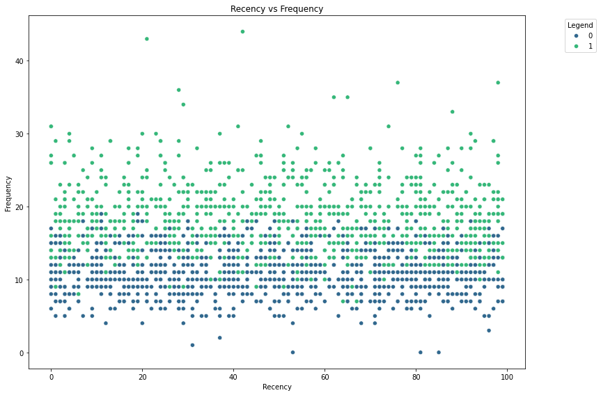

```python
# Define a color palette
palette = 'viridis'

plt.figure(figsize=(12, 8))

# Using seaborn's scatter plot with a KDE overlay for each cluster
sns.scatterplot(data=df, x='Recency', y='Frequency', hue='cluster', palette=palette, alpha=1)

plt.title('Recency vs Frequency')
plt.xlabel('Recency')
plt.ylabel('Frequency')
plt.legend(title='Legend', loc='upper right', bbox_to_anchor=(1.15, 1))
plt.tight_layout()
plt.show()
```

**Though not very distinct in terms of recency, cluster one consists of more frequent buyers relative to cluster 0.**

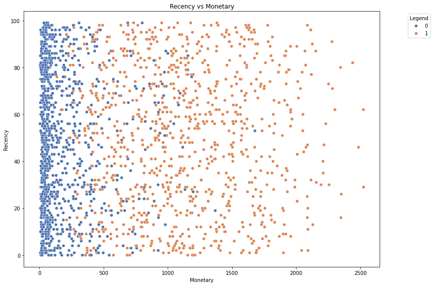

```python
palette = 'deep'


plt.figure(figsize=(12, 8))

# Using seaborn's scatter plot with a KDE overlay for each cluster
sns.scatterplot(data=df, x='Monetary', y='Recency', hue='cluster', palette=palette, alpha=1)

plt.title('Recency vs Monetary')
plt.xlabel('Monetary')
plt.ylabel('Recency')
plt.legend(title='Legend', loc='upper right', bbox_to_anchor=(1.15, 1))
plt.tight_layout()
plt.show()
```

**Whereas, cluster 1 are large spenders relative to cluster 0.**

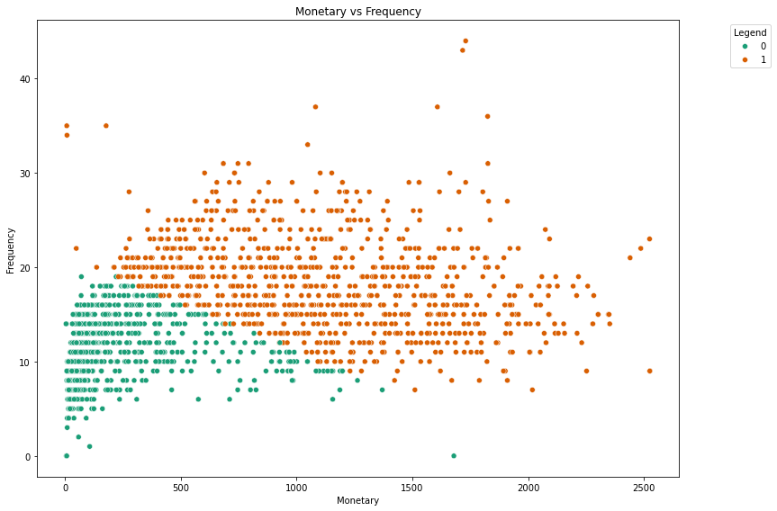

```python
plt.figure(figsize=(12, 8))

# Using seaborn's scatter plot with a KDE overlay for each cluster
sns.scatterplot(data=df, x='Monetary', y='Frequency', hue='cluster', palette='Dark2', alpha=1)

plt.title('Monetary vs Frequency')
plt.xlabel('Monetary')
plt.ylabel('Frequency')
plt.legend(title='Legend', loc='upper right', bbox_to_anchor=(1.15, 1))
plt.tight_layout()
plt.show()
```

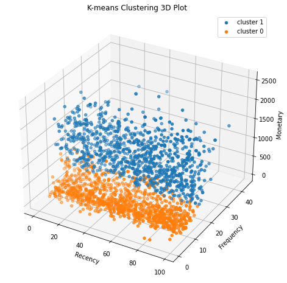

```python
from mpl_toolkits.mplot3d import Axes3D


# Create figure and 3D axes
fig = plt.figure(figsize=(10, 8))
ax = fig.add_subplot(111, projection='3d')

# Scatter plot for each cluster, first I utilize .unique, to attain the unique cluster values, in this case that would be 0 and 1
#After this I filter the dataframe for the clusters that match the current iteration, extracting the recency, frequency
# And monetary values from said columns
#The final line label is used by Matplotlib to help generate a legend that explains which points belong to which cluster
for cluster in df['cluster'].unique():
    ax.scatter(df[df['cluster'] == cluster]['Recency'],
               df[df['cluster'] == cluster]['Frequency'],
               df[df['cluster'] == cluster]['Monetary'],
               label=f'cluster {cluster}')

#To Set labels and title
ax.set_xlabel('Recency')
ax.set_ylabel('Frequency')
ax.set_zlabel('Monetary')
ax.set_title('K-means Clustering 3D Plot')
ax.legend()

plt.show()
```

# Education Level - Cluster Analysis

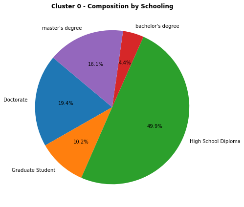

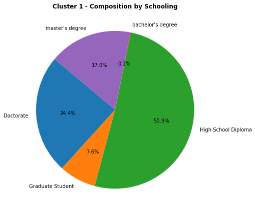

```python
# Calculate the composition of each cluster in terms of schooling
#This line of code, groups the dataset in unique cluster-education values, after which size creates an additional column
#In which the size of each unique pair is noted
#After which unstack creates a new dataframe, tranforming the different education levels into their respective columns
cluster_composition = df.groupby(['cluster', 'Education']).size().unstack()


# In this case, we have two values for composition that is 0 and 1. Within the loop we loc onto the row with index (cluster) 0
# In addition to the row with index(cluster) 1 and extract those values into composition
for cluster in cluster_composition.index:
    composition = cluster_composition.loc[cluster]

#Created a figure and axes with width of 8 inches and height of 6 inches
    fig,ax=plt.subplots(figsize=(8, 6))

# Plot pie chart, where composition captures the values within each row of the new dataframe, the index of this
# New dataframe is cluster,
    ax.pie(composition, labels=composition.index, autopct='%1.1f%%', startangle=140)

    # Set title
    ax.set_title(f'Cluster {cluster} - Composition by Schooling',fontweight='bold')

    # Show plot
    plt.tight_layout()
    plt.show()
```

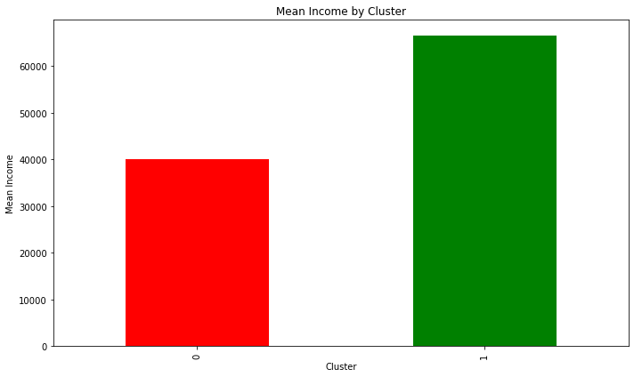

```python
mean_income_cluster = df.groupby('cluster')['Income'].mean()
#To plot a barchart
colors=['red','green']
plt.figure(figsize=(10, 6))
mean_income_cluster.plot(kind='bar', color=colors)

# Setting title and labels
plt.title('Mean Income by Cluster')
plt.xlabel('Cluster')
plt.ylabel('Mean Income')

# Show plot
plt.tight_layout()
plt.show()
```

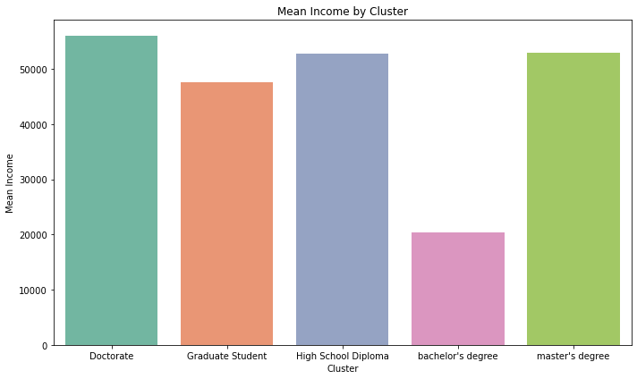

```python
mean_income_education = df.groupby('Education')['Income'].mean().reset_index()
#To plot a barchart

plt.figure(figsize=(10, 6))
sns.barplot(x='Education', y='Income', data=mean_income_education, palette='Set2',hue='Education',legend=False)

# Setting title and labels
plt.title('Mean Income by Cluster')
plt.xlabel('Cluster')
plt.ylabel('Mean Income')

# Show plot
plt.tight_layout()
plt.show()
```

[figure not shown]

```python
mean_age_education = df.groupby('Education')['Customer_Age'].mean().reset_index()
#To plot a barchart

plt.figure(figsize=(10, 6))
sns.barplot(x='Education', y='Customer_Age', data=mean_age_education, palette='Set2',hue='Education',legend=False)

# Setting title and labels
plt.title('Mean Income by Cluster')
plt.xlabel('Education')
plt.ylabel('Average Age')

# Show plot
plt.tight_layout()
plt.show()
```

```python
df.groupby('Education')['Customer_Age'].mean()
```

```
Education
Doctorate              57.818557
Graduate Student       51.223881
High School Diploma    54.364685
bachelor's degree      46.537037
master's degree        57.121622
Name: Customer_Age, dtype: float64
```

# Household Size - Cluster Analysis

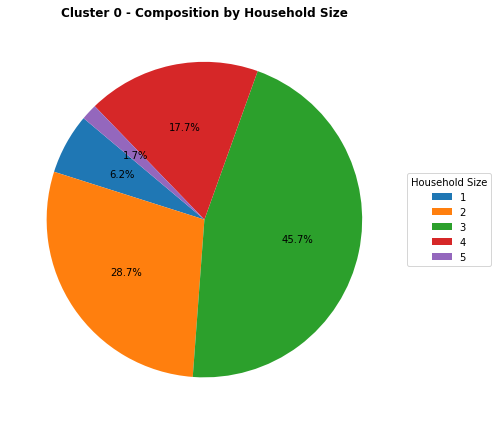

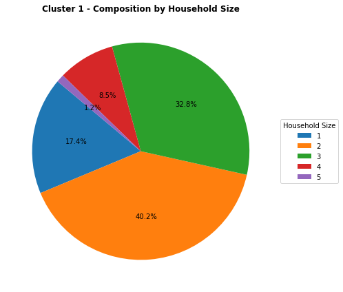

```python
# Calculate the composition of each cluster in terms of schooling
#This line of code, groups the dataset in unique cluster-household size values, after which size creates an additional column
#In which the size of each unique pair is noted
#After which unstack creates a new dataframe, tranforming the different household sizes into their respective columns
cluster_composition = df.groupby(['cluster', 'Household_Size']).size().unstack()


# In this case, we have two values for composition that is 0 and 1. Within the loop we loc onto the row with index (cluster) 0
# In addition to the row with index(cluster) 1 and extract those values into composition
for cluster in cluster_composition.index:
    composition = cluster_composition.loc[cluster]

#Created a figure and axes with width of 8 inches and height of 6 inches
    fig,ax=plt.subplots(figsize=(8, 6))

# Plot pie chart, where composition captures the values within each row of the new dataframe, the index of this
# New dataframe is cluster,
    ax.pie(composition, labels=None, autopct='%1.1f%%', startangle=140)
    ax.legend(composition.index, title="Household Size", loc="center left", bbox_to_anchor=(1, 0, 0.5, 1))

    # Set title
    ax.set_title(f'Cluster {cluster} - Composition by Household Size',fontweight='bold')

    # Show plot
    plt.tight_layout()
    plt.show()
```

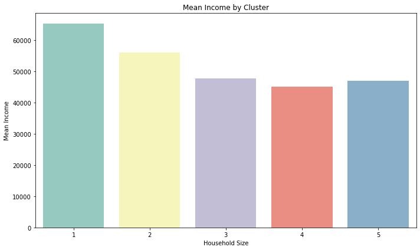

```python
mean_income_household = df.groupby('Household_Size')['Income'].mean().reset_index()
#To plot a barchart

plt.figure(figsize=(10, 6))
sns.barplot(x='Household_Size', y='Income', data=mean_income_household, palette='Set3',hue='Household_Size',legend=False)

# Setting title and labels
plt.title('Mean Income by Cluster')
plt.xlabel('Household Size')
plt.ylabel('Mean Income')

# Show plot
plt.tight_layout()
plt.show()
```

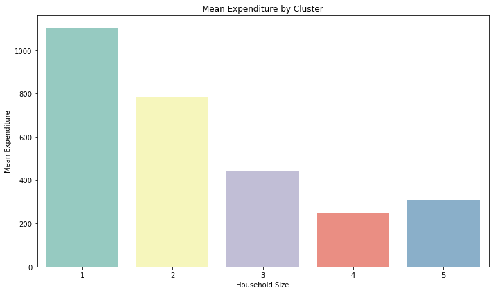

```python
mean_expenditure_household = df.groupby('Household_Size')['Monetary'].mean().reset_index()
#To plot a barchart

plt.figure(figsize=(10, 6))
sns.barplot(x='Household_Size', y='Monetary', data=mean_expenditure_household, palette='Set3',hue='Household_Size',legend=False)

# Setting title and labels
plt.title('Mean Expenditure by Cluster')
plt.xlabel('Household Size')
plt.ylabel('Mean Expenditure')

# Show plot
plt.tight_layout()
plt.show()
```

By observing the graphs, one can see the biggest disparity, is with households of three, four and five. The business' most loyal households are those which are smaller (1-2) individuals. The entity could offer family-oriented products, family discounts and packages. The business can delve into the toy market to attract more children, enticing their parents and guardians to purchase more for the family, this will narrow the gap between the mean expenditure and income for those household groups.

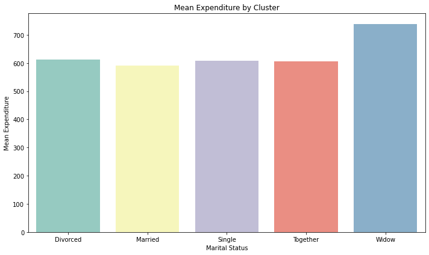

```python
mean_marriage_exp=df.groupby('Marital_Status')['Monetary'].mean().reset_index()
plt.figure(figsize=(10, 6))
sns.barplot(x='Marital_Status', y='Monetary', data=mean_marriage_exp, palette='Set3',hue='Marital_Status',legend=False)

plt.title('Mean Expenditure by Cluster')
plt.xlabel('Marital Status')
plt.ylabel('Mean Expenditure')

# Show plot
plt.tight_layout()
plt.show()
```

[figure not shown]

```python
mean_marriage_income=df.groupby('Marital_Status')['Income'].mean().reset_index()
plt.figure(figsize=(10, 6))
sns.barplot(x='Marital_Status', y='Income', data=mean_marriage_income, palette='Set3',hue='Marital_Status',legend=False)

plt.title('Mean Expenditure by Cluster')
plt.xlabel('Marital Status')
plt.ylabel('Mean Income')

# Show plot
plt.tight_layout()
plt.show()
```

```python
df['Expenditure_Percentage']=(df['Monetary']/df['Income'])*100
df.groupby('Marital_Status')['Expenditure_Percentage'].mean().reset_index()
```

|  | Marital_Status | Expenditure_Percentage |
| --- | --- | --- |
| 0 | Divorced | 0.964654 |
| 1 | Married | 1.015072 |
| 2 | Single | 0.975267 |
| 3 | Together | 0.954473 |
| 4 | Widow | 1.174469 |

Widows have the highest income, but also spend the most at the store relative to their income, they spend a little over 1 percent of their income, whereas people who are simply together but unmarried, spend just under 1% of their income. Married individuals spend a little over 1% of their income as well. All groups here spend roughly, 1% of their income at the store, as such there is not a group to single out, due to lack of expenditure.